# Final Exam Replacement Report

#### 2) Assumptions

##### Normality Assumption

First, we will check normality assumption by shapiro-test.

```r
shapiro.test(data[data$class=="1", 1])
```

```
##
##  Shapiro-Wilk normality test
##
## data:  data[data$class == "1", 1]
## W = 0.75, p-value < 2.2e-16
```

```r
shapiro.test(data[data$class=="2", 1])
```

```
##
##  Shapiro-Wilk normality test
##
## data:  data[data$class == "2", 1]
## W = 0.78353, p-value = 0.009139
```

```r
shapiro.test(data[data$class=="3", 1])
```

```
##
##  Shapiro-Wilk normality test
##
## data:  data[data$class == "3", 1]
## W = 0.89061, p-value = 0.1415
```

```r
shapiro.test(data[data$class=="4", 1])
```

```
##
##  Shapiro-Wilk normality test
##
## data:  data[data$class == "4", 1]
## W = 0.96137, p-value = 0.8302
```

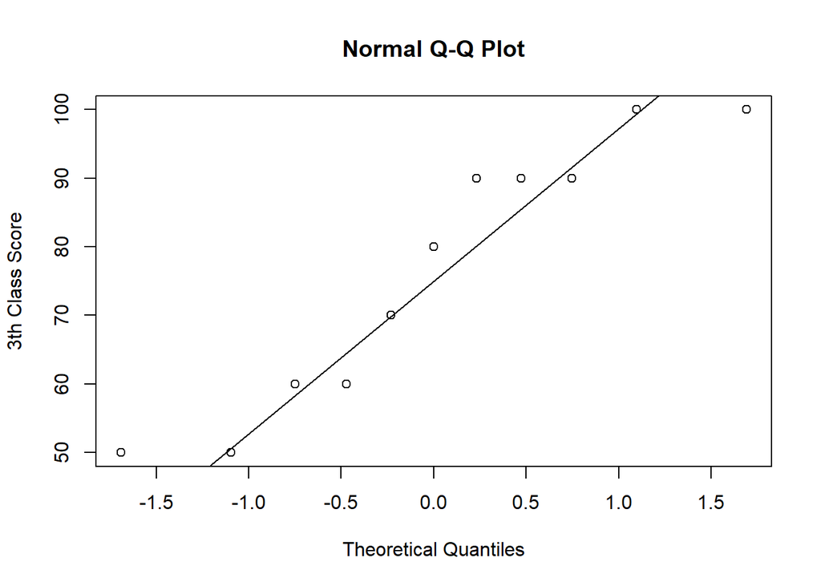

```r
qqnorm(data[data$class=="3", 1], ylab = "3th Class Score")
qqline(data[data$class=="3", 1])
```

As you can see the figure, the score is around the straight line, but, there are just two score in the bottom and top of the figure which are a little far from straight line and we ignore it. So we can conclude that the score for 3th class is roughly normal.

Let’s see qqplot for 4th class score.

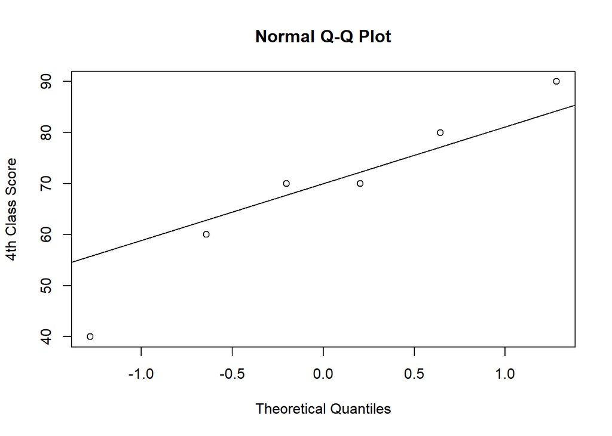

```r
qqnorm(data[data$class=="4", 1], ylab = "4th Class Score")
qqline(data[data$class=="4", 1])
```

The 4th class score is also around the straight line and there is one score which is a little far from the straight line which we ignore it. As a result we can say score for 4th class is roughly normal.

##### Variance homogeneity

```r
bartlett.test(score~class, data=data)
```

```
##
##  Bartlett test of homogeneity of variances
##
## data:  score by class
## Bartlett's K-squared = 4.6172, df = 3, p-value = 0.2021
```

Based on output of barlett-test, p-value > 0.05 So, the null hypothesis is not rejected and variances are equal.

#### 3) Analysis of variance

```r
model<-aov(score~class, data=data)
summary(model)
```

```
##             Df Sum Sq Mean Sq F value Pr(>F)
## class        3   1402   467.4   1.931  0.149
## Residuals   26   6295   242.1
```

The p-value > 0.05, we can conclude that there is no significant differences between the classes score.  
As there is no significant difference between the classes score, we cannot conduct Posthoc-test.  
Also unfortunately, there are not enough data(students scores) based on faculty and age, So we can’t conduct ANOVA on them.

## Linear Regression

Though building a linear regression model might not be necessary or might not have any implication for an awareness test, I would like to just discover linear regression and its functions.

First, I will prepare dependent and independent variables. I will choose score as dependent variable.

```r
# Get relevant columns
reg.df <- df[, c(4, 5, 6, 7, 19, 2)]

# convert age and class to numeric type
reg.df$age <- as.numeric(as.character(reg.df$age))
reg.df$Sinif <- as.numeric(as.character(reg.df$Sinif))

head(reg.df)
```

```
##   Cinsiyet               Fakulte Sinif     Vatandaslik age Score
## 1    Erkek Muhendislik Fakultesi     3 Yabanci Uyruklu  25    60
## 2    Erkek      Egitim Fakultesi     4 Yabanci Uyruklu  23    70
## 3    Erkek Muhendislik Fakultesi     3 Yabanci Uyruklu  21    50
## 4    Erkek Muhendislik Fakultesi     3    Turk Uyruklu  23    90
## 5    Erkek Muhendislik Fakultesi     3 Yabanci Uyruklu  23    50
## 6    Kadin Muhendislik Fakultesi     2    Turk Uyruklu  22    90
```

Now the data is ready.

```r
# correlation for class, age and score
cor(reg.df[,c(3, 5, 6)])
```

```
##            Sinif        age       Score
## Sinif 1.00000000  0.4403062  0.03825095
## age   0.44030625  1.0000000 -0.14764071
## Score 0.03825095 -0.1476407  1.00000000
```

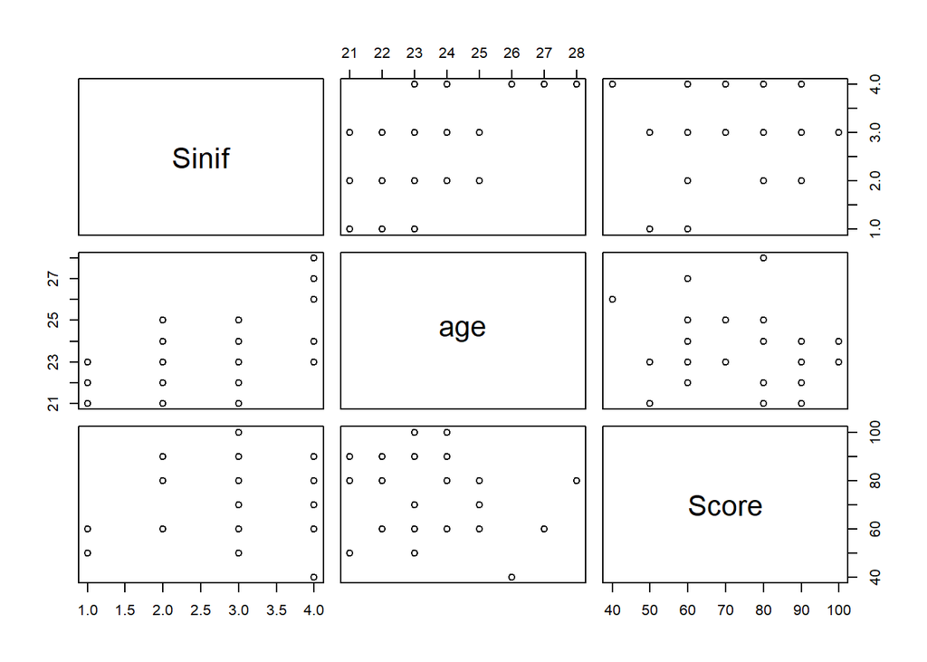

```r
plot(reg.df[,c(3, 5, 6)])
```

There were just 3 numeric values in our dataset. Based on above output we can conclude as following:

- There is no correlation between score and class
- There is weak negative correlation between score and age.  
  Does this mean, increase in age cause lower awareness score?  
  Well, the answer is: No, Correlation always does not imply causation!
- And lastly, there is moderate correlation between class and age

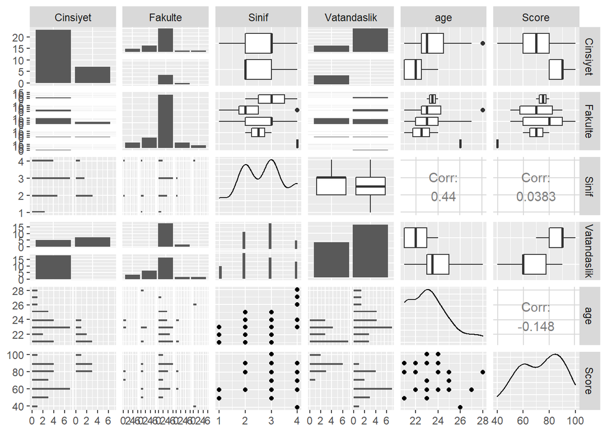

```r
ggpairs(reg.df, cardinality_threshold=30)
```

```r
# Fitting Multiple Linear Regression to the Training set
model = lm(formula = Score ~ .,
               data = reg.df)


summary(model)
```

```
##
## Call:
## lm(formula = Score ~ ., data = reg.df)
##
## Residuals:
##      Min       1Q   Median       3Q      Max
## -16.9714  -6.0622   0.1288   4.4706  21.9750
##
## Coefficients:
##                                             Estimate Std. Error t value
## (Intercept)                                   25.674     27.838   0.922
## CinsiyetKadin                                 -1.390      5.993  -0.232
## FakulteIktisadi ve Idari Bilimler Fakultesi   -9.281      8.740  -1.062
## FakulteMuhendislik Fakultesi                 -15.211      7.723  -1.970
## FakulteSaglik Bilimleri Fakultesi            -19.182     10.147  -1.890
## FakulteTeknoloji Fakultesi                   -40.859     12.327  -3.314
## Sinif                                         -4.348      2.633  -1.651
## VatandaslikYabanci Uyruklu                   -33.571      6.305  -5.324
## age                                            4.083      1.384   2.950
##                                             Pr(>|t|)
## (Intercept)                                  0.36686
## CinsiyetKadin                                0.81887
## FakulteIktisadi ve Idari Bilimler Fakultesi  0.30033
## FakulteMuhendislik Fakultesi                 0.06221 .
## FakulteSaglik Bilimleri Fakultesi            0.07259 .
## FakulteTeknoloji Fakultesi                   0.00330 **
## Sinif                                        0.11353
## VatandaslikYabanci Uyruklu                   2.8e-05 ***
## age                                          0.00765 **
## ---
## Signif. codes:  0 '***' 0.001 '**' 0.01 '*' 0.05 '.' 0.1 ' ' 1
##
## Residual standard error: 9.771 on 21 degrees of freedom
## Multiple R-squared:  0.7395, Adjusted R-squared:  0.6402
## F-statistic: 7.451 on 8 and 21 DF,  p-value: 0.0001055
```

```r
vif(model)
```

```
##                 GVIF Df GVIF^(1/(2*Df))
## Cinsiyet    2.018619  1        1.420781
## Fakulte     1.555545  4        1.056782
## Sinif       1.790565  1        1.338120
## Vatandaslik 2.997822  1        1.731422
## age         1.969470  1        1.403378
```

```r
reduced.model<-step(model)
```

```
## Start:  AIC=144.07
## Score ~ Cinsiyet + Fakulte + Sinif + Vatandaslik + age
##
##               Df Sum of Sq    RSS    AIC
## - Cinsiyet     1      5.13 2010.2 142.14
## <none>                     2005.1 144.07
## - Sinif        1    260.40 2265.5 145.73
## - Fakulte      4   1197.02 3202.1 150.11
## - age          1    830.77 2835.9 152.47
## - Vatandaslik  1   2706.86 4712.0 167.70
##
## Step:  AIC=142.14
## Score ~ Fakulte + Sinif + Vatandaslik + age
##
##               Df Sum of Sq    RSS    AIC
## <none>                     2010.2 142.14
## - Sinif        1     257.5 2267.8 143.76
## - Fakulte      4    1210.9 3221.1 148.29
## - age          1     825.6 2835.9 150.47
## - Vatandaslik  1    4148.4 6158.6 173.73
```

```r
summary(reduced.model)
```

```
##
## Call:
## lm(formula = Score ~ Fakulte + Sinif + Vatandaslik + age, data = reg.df)
##
## Residuals:
##      Min       1Q   Median       3Q      Max
## -16.3311  -6.2090  -0.1948   5.0561  21.9923
##
## Coefficients:
##                                             Estimate Std. Error t value
## (Intercept)                                   24.910     27.041   0.921
## FakulteIktisadi ve Idari Bilimler Fakultesi   -9.170      8.537  -1.074
## FakulteMuhendislik Fakultesi                 -15.101      7.540  -2.003
## FakulteSaglik Bilimleri Fakultesi            -19.378      9.892  -1.959
## FakulteTeknoloji Fakultesi                   -40.940     12.055  -3.396
## Sinif                                         -4.206      2.506  -1.679
## VatandaslikYabanci Uyruklu                   -32.668      4.848  -6.738
## age                                            4.059      1.350   3.006
##                                             Pr(>|t|)
## (Intercept)                                  0.36694
## FakulteIktisadi ve Idari Bilimler Fakultesi  0.29443
## FakulteMuhendislik Fakultesi                 0.05769 .
## FakulteSaglik Bilimleri Fakultesi            0.06291 .
## FakulteTeknoloji Fakultesi                   0.00259 **
## Sinif                                        0.10734
## VatandaslikYabanci Uyruklu                  9.01e-07 ***
## age                                          0.00650 **
## ---
## Signif. codes:  0 '***' 0.001 '**' 0.01 '*' 0.05 '.' 0.1 ' ' 1
##
## Residual standard error: 9.559 on 22 degrees of freedom
## Multiple R-squared:  0.7388, Adjusted R-squared:  0.6557
## F-statistic:  8.89 on 7 and 22 DF,  p-value: 3.393e-05
```

We should check the residual plot to see if the assumptions of our model are reasonable. Our simple linear regression model assumes that the theoritical error terms are normally distributed and have constant variance and are independent of one another.

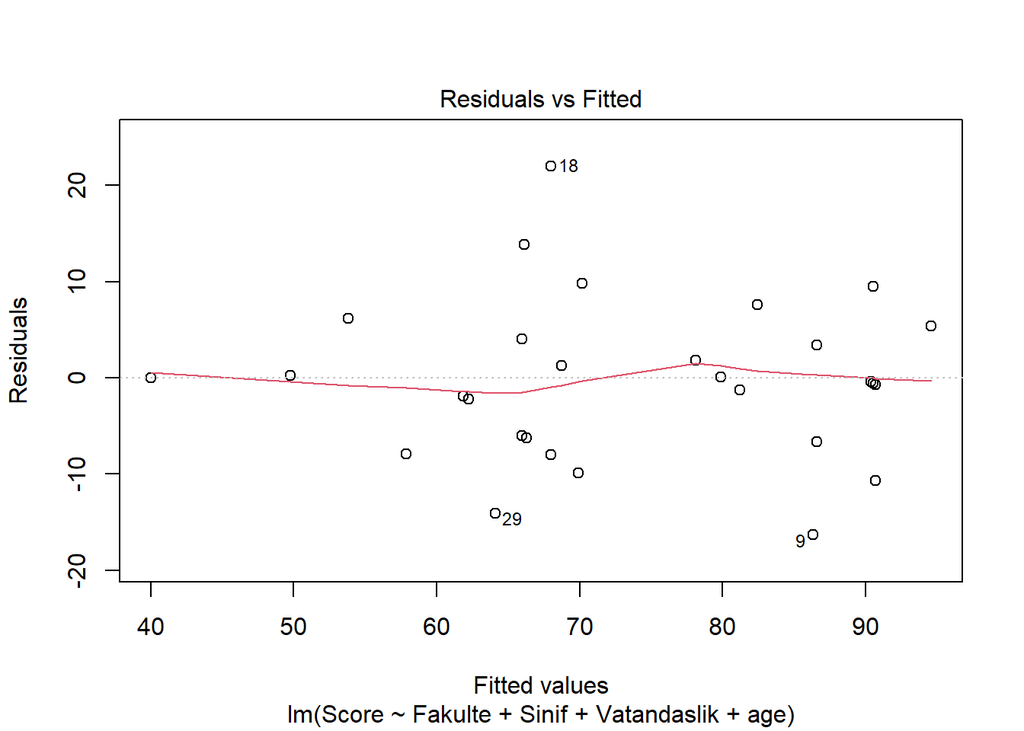

```r
plot(reduced.model, which = 1)
```

Above plot indicates that by increasing x values, the variability for residual also decreases and increases by some outliers(9, 18 and 29) in the data. So, something systematic is going on and there is a problem with our assumed model. Also it is against the regression assumptions.  
Note: Using my sixth sense, it looks the variability is not pretty high. So it might be normal.  
Some more experience or knowledge is required for better interpretation.

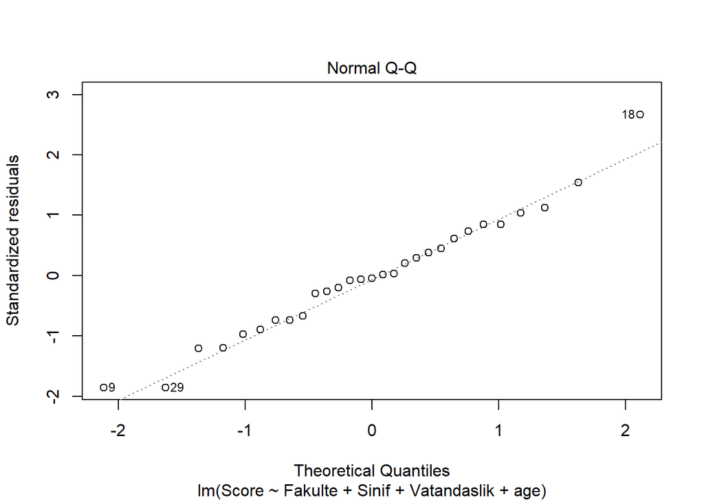

```r
plot(reduced.model, which = 2)
```

The residual is approximately normal, so it passes the normality assumption.

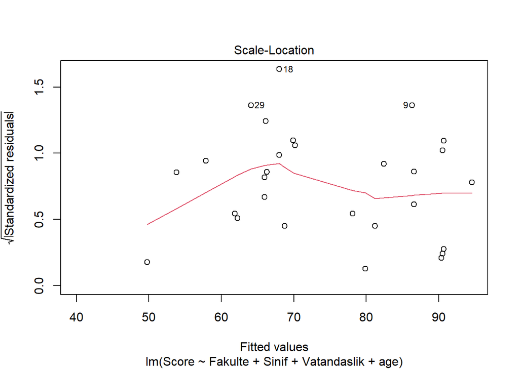

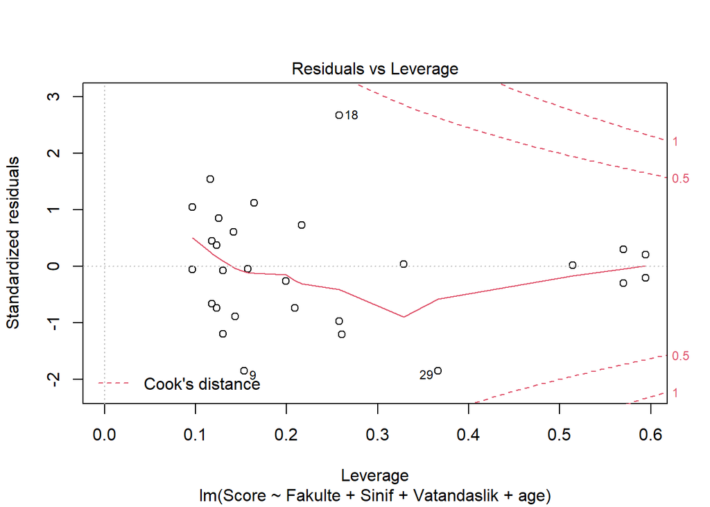

```r
plot(reduced.model, which = c(3, 5))
```

## Discussion:

- What implications do your results have for the population you sampled from?

  The method used for sampling was simple random sampling, I did my best to send the test to all of students in different faculties, but it looks, it didn’t reach to all. If this study is about to be done again, I would choose stratified sampling method. Also, the sample size was very small, So increasing the sample size might improve this study. Furthermore, the test was prepared in Turkish language, so it was easily understandable by Turkish students, but it might not be enough understandable by foreigner students. So, for next time it would be better to prepare in both English and Turkish language.
- What types of biases might exist?

  I think undercoverage and voluntary response biases might exist in this survey.